# What Predicts Repayment Difficulty?

Home Credit application data · [Kaggle competition](https://www.kaggle.com/competitions/home-credit-default-risk)

Evan Reynolds

## The Short Version

8.07%repayment difficulty across all applications

Raw loan amount shows no clear pattern on its own.

Driver performance is compared with the 8.07% portfolio default rate.

## Dataset Overview

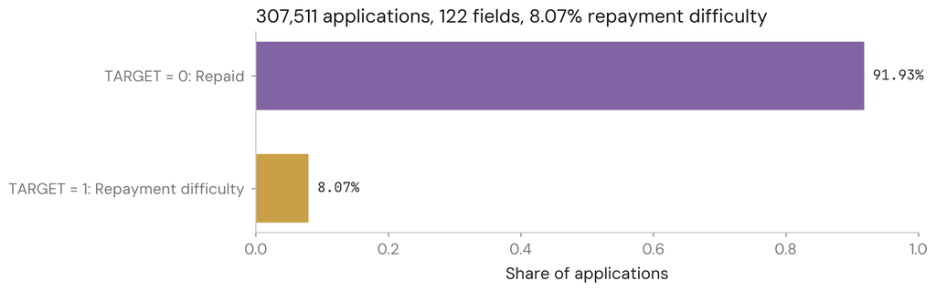

**Class imbalance:** repayment difficulty affects 8.07% of applications, about 11 repaid applications for every one with difficulty. Each group is therefore read against the 8.07% line.

## How to Read the Charts

Each bar is a group’s repayment-difficulty rate, compared with the **8.07% portfolio rate** (dashed line).

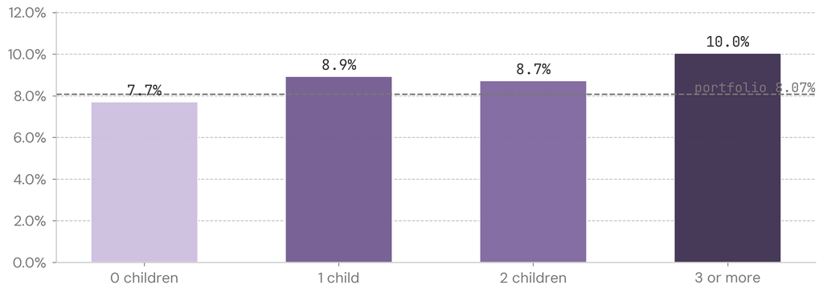

Lighter = lower repayment difficulty, darker = higher. **Bars that move away from the line show separation; bars close to it show little.**

## External Credit Scores

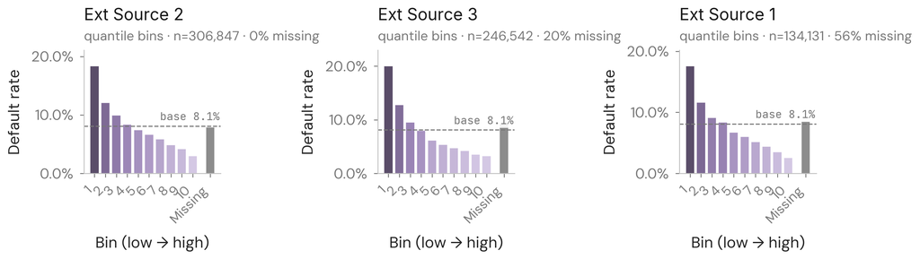

**External credit scores show the strongest separation in default rates among the screened variables.**

## Age and Job Tenure

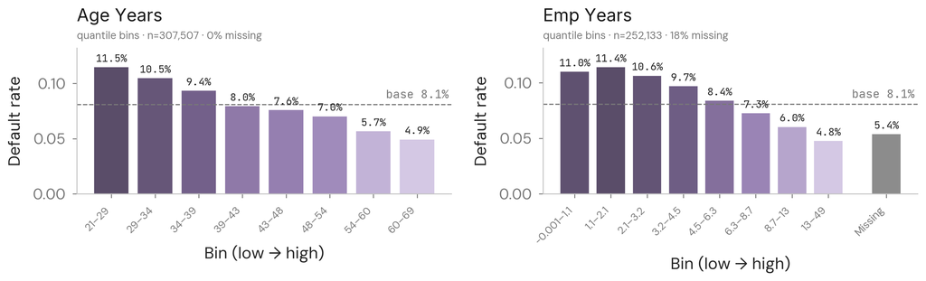

**Default rates are higher among younger applicants and those with shorter job tenure.** The missing job-tenure bin is pensioners, whose rate is low.

## Education

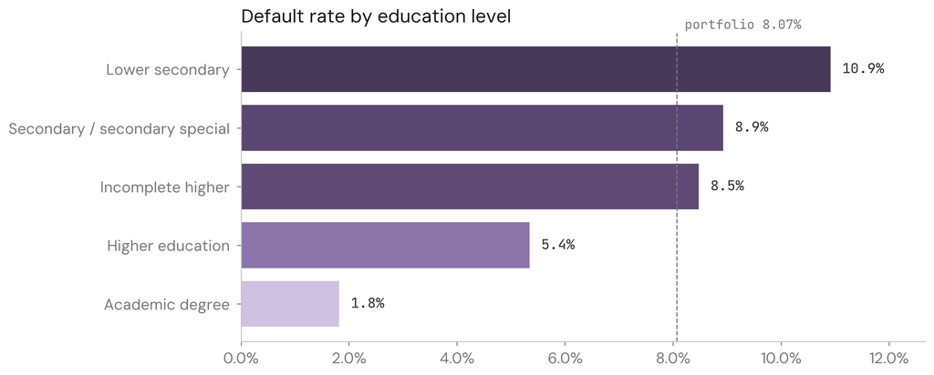

Default rates rise as education level falls, from **1.8%** for academic degree to **10.9%** for lower secondary.

## Loan Amount

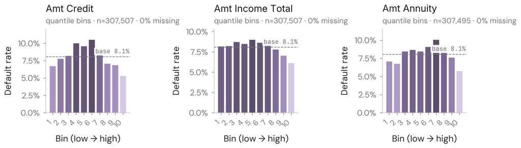

**Default rate does not show a clear monotonic relationship with loan amount.**

## Affordability Ratios

LVR = loan ÷ goods price · Employed-to-Age = job tenure ÷ age · Debt-to-Income = annuity ÷ income

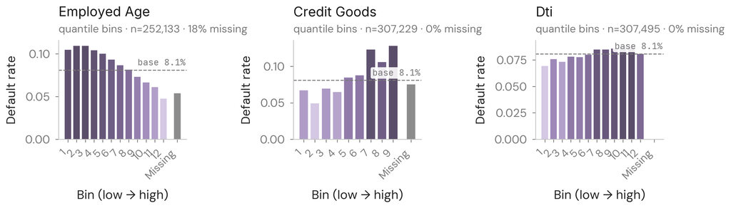

**Employed-to-Age and LVR separate risk across groups. Debt-to-Income shows no clear pattern.**

## WOE and Information Value

| Feature | Information Value | Decision |
| --- | --- | --- |
| External Credit Score 3 | 0.334 | Retained |
| External Credit Score 2 | 0.320 | Retained |
| External Credit Score 1 | 0.149 | Retained |
| Job Tenure | 0.116 | Retained |
| Annuity-to-Credit Ratio | 0.112 | Retained |
| Employed-to-Age Ratio | 0.092 | Retained |
| Goods Price | 0.091 | Retained |
| Days Birth | 0.091 | Retained |
| Occupation | 0.079 | Retained |
| Credit-to-Goods Ratio (LVR) | 0.074 | Retained |
| Organisation Band | 0.072 | Retained |
| Loan Amount | 0.059 | Retained |

Top 12 of 87 screened features. **IV cutoff: 0.02.** Features above the cutoff move forward to logistic model development.

## From Scan to Scorecard

Selected features now move into logistic PD model development.